# Course Introduction and the Study of American Government

POLS 2311: Government of the United States

## Agenda

### Course Introduction and the Study of American Government

- Syllabus
- What is government?
- Why do we need government?
- Forms of government
- Who governs?
- The political agenda
- The politics of policy issues

# Syllabus

## Instructors

**Your Professor**

- Dr. Matthew C. Nowlin, Ph.D.
- Email: matthew.nowlin@uta.edu
- Office Hours: By appointment. Email me!

**Your Teaching Assistants**

- **Jake Flowers**: jmf3765@mavs.uta.edu

# Syllabus - it’s on canvas, download it

## What is this course about?

**This course is designed to introduce students to the core concepts of American government and politics.**

- The emphasis of this course will be placed on approaching topics associated with government and politics as *social scientists*

## Three Parts

- Part I: The Constitutional Order and the American Political System
- Part II: Formal Institutions
- Part III: Individual Agency and Mediating Institutions

## Learning Outcomes

1. Identify and explain the central principles, institutions, procedures, and decision-making processes of the American political system
2. Evaluate the basic strengths and weaknesses of the American political system through the application of political concepts and ideas
3. Relate historical events and/or developments to contemporary political issues, debates, and outcomes in the United States
4. Develop an analytical, social science disposition toward American politics

## Course Information

- **Readings**
  - Book: Wilson, James, John DiIulio Jr, Meena Bose, and Matthew Levendusky. 2025. *American Government: Institutions & Policies*. 18th ed. Cengage Learning.
  - **The book is available through the UTA bookstore**
  - In general, read half of the readings for Mondays and the other half for Wednesdays
  - You will have weekly quizzes over the readings

## Course Information

- **Attendance Policy**
  - Attendance will be taken, each class session is worth ~4 points, and lecture slides will **not** be posted on Canvas
- **Technology Policy**
  - *Laptops are not allowed in class*
  - Phones should be put away at all times
  - AI is **not** to be used for quizzes or exams in this class
- **Late Work Policy**
  - Late work will not be accepted
- **Extra Credit**
  - There will be no opportunities for extra credit in this course

## Assignments

**Assignments and Points (700 points possible)**

- Quizzes: 200 points total
  - 11 multiple choice quizzes (20 points each); *lowest quiz score will be dropped*
  - 10 multiple choice questions; 5 minutes to complete
  - Available on Canvas Monday morning, and due by Friday night at 11:59 PM
  - *LockDown Browser*: see information on Canvas

## Assignments

**Assignments and Points (700 points possible)**

- Exams: 400 points total
  - Exam 1: 100 points. **IN CLASS?, Wed Sept 23**
  - Exam 2: 100 points. **IN CLASS?, Wed Oct 28**
  - Final Exam: 200 points. **Comprehensive, IN CLASS?, Wednesday, December 9 from 11-1:30**
- Attendance: 100 points

## Quick Overview of Topics

- Part I: The Constitutional Order and the American Political System
  - The Constitution
  - Federalism
  - Civil liberties
  - Civil rights
  - Political culture
- Part II: Formal Institutions
  - Congress
  - The presidency
  - The bureaucracy
  - The courts
  - The federal budget

## Quick Overview of Topics

- Part III: Individual Agency and Mediating Institutions
  - Public opinion
  - Political participation
  - Political parties
  - Election and campaigns
  - Interest groups

## How to Well in this Course

- Do the readings and take *handwritten notes*
  - Look for headings and sub-headings
  - Look for **terms in bold**
- Attend class and take *handwritten notes*
  - Ask when something isn’t clear
- Digitize your handwritten notes
  - Use AI to help you organize *your notes*
- Review your digitized notes
  - Before quizzes
  - Before exams

# Questions?

## What is this course about?

**This course is designed to introduce students to the core concepts of American government and politics.**

# What is Government?

## Government and Politics

- A **government** *is the system by which a society organizes itself and allocates authority in order to accomplish collective goals and provide benefits to that society*
- **Politics** *refers to the process of gaining or exercising control within a government by an association of persons with shared goals or objectives for society*
  - *is the activity by which an issue is agitated or settled*.
  - *Who gets what, when, how* (*Lasswell, 1936*)

## Power, Authority, and Legitimacy

- **Power**: *The ability of one person to get another person to act in accordance with the first person’s intentions*
- **Authority**: *The right to use power*
- **Legitimacy**: *Political authority conferred by law or by a state or national constitution*
  - In the US, the Constitution is widely accepted as a source of legitimate authority

# What Would Life Be Like With No Government?

[figure not shown]

# *The State of Nature*

## The State of Nature: Hobbes

### Leviathan (1651)

- “*the condition of man.. is a condition of war of everyone against everyone*”
- “*the life of man is solitary, poore, nasty, brutish, and short*”

[figure not shown]

## The Social Contract

*An agreement between people and their leaders in which the people agree to give up some of their liberties so that their other liberties are protected*

## The Social Contract: Hobbes

### Leviathan (1651)

- **Social Contract**: Absolute monarch
  - The surrender of individual liberty for security

## Locke

### Two Treatises on Civil Government (1689)

- Individuals possess certain unalienable rights
  - *life, liberty, and …*
- In the *State of Nature* no protection of *natural rights*
- **Social Contract**: Government that protects natural rights
  - *Consent of the governed*

[figure not shown]

# Forms of Government

## Government

- A **government** *is the system by which a society organizes itself and allocates authority in order to accomplish collective goals and provide benefits to that society*
- *Questions of* …
  - **Power**
  - **Authority**
  - **Legitimacy**

## Forms of Government

### Aristotle

- Two axes: *who* rules (one, few, many) and *for whose interest* (common good, or private interest of the rulers)

| Rulers | True Form (Common Interest) | Perversion (Private Interest) |
| --- | --- | --- |
| One | Monarchy | Tyranny |
| Few | Aristocracy | Oligarchy |
| Many | Polity | Democracy |

## Forms of Government

### Authoritarian

- **Authoritarianism**: Absence of citizen control over government
  - *Dictatorships*: One leader
  - *Monarchies*: Leaders emerge from a ruling family
  - *One-party states*: a ruling party runs the country with no political competition
  - *Totalitarian*: no limits on government power
  - *Competitive Authoritarianism*: elections are held, but are unfair

## Forms of Government

### Socialism

- **Socialism**: *Society as a whole, and not private individuals, owns and controls property for the benefit of all*
  - Centralized: Government owns the means of production
  - Decentralized: Communities owns the means of production
  - *Democratic Socialism*: Combines political democracy with an economy more democratically controlled by workers and the public
- **Communism**: *A classless society in which the major means of production are owned and controlled by the public*
  - In its strict form: no government, no private property, no currency
  - Socialism is often treated as the transitional phase toward fully realized communism

## Forms of Government

### Oligarchy

- **Oligarchy**: A form of government in which a small class of political and economic elites control the government
  - *Power-elite view in the extreme*

## Forms of Government

### Fascism

- **Fascism**: *Individuals and classes are to be absorbed into an all-embracing whole*
  - *Nationalism*: Nation-state built around a shared ethic identity
  - *National socialism*: Nazism
    - Used the word *socialist* in its name partly to appeal to the German working class in the 1920s

# What about the United States?

# “*We’re a Republic, Not a Democracy*”

## Forms of Government

### Democracy

- **Democracy**: *The rule of many*
  - *A form of government in which political power–influence over institutions, leaders, and policies–is controlled by the people*
- *Direct or Participatory Democracy*: A government in which all or most citizens participate directly
- *Representative Democracy*: A government in which leaders make decisions by winning a competitive struggle for the popular vote

## Forms of Government

### Republic

- **Republic**: a government with **no monarch** — sovereignty derives from the citizens
- **Democracy**: the people hold power
- These describe **different dimensions** of government and are not opposites:
  - Republic **and** democracy: United States, France
  - Republic, **not** a democracy: People’s Republic of China
  - Democracy, **not** a republic: United Kingdom (retains a monarch)
  - Neither: Saudi Arabia

## Madison’s Republic

### *Federalist* 10 & 14

- A **pure democracy**: “a society… who assemble and administer the government in person”
- A **republic**: “a government in which the scheme of representation takes place”
- In modern terms, what Madison called a “republic” is simply **representative democracy**

[figure not shown]

## Majority Rule and Minority Rights

- **Majority rule**: the opinions of the majority carry more weight in government decisions
- **Minority rights**: people cannot be deprived of certain rights — free speech, due process, equal protection — even if an overwhelming majority wants to

# How democratic is the United States?

## Dahl’s Criteria for a Democratic Process

- *All members of a polity should be treated as **equally qualified** to participate in decisions about the policies that govern them* (Robert Dahl)
- Five criteria:
  - **Effective participation** — equal opportunity to make your views known
  - **Equality in voting** — equal opportunity to vote, all votes counted equally
  - **Enlightened understanding** — equal opportunity to learn about alternatives and consequences
  - **Control of the agenda** — members retain final say over what is decided
  - **Inclusion of adults** — the above rights extend to (nearly) all adult members

## Threats to Democracy

- **Tyranny of the majority**: majorities using democratic power to oppress minorities
- **Political ignorance**: most voters know very little about government or policy; this is largely a *rational* response, since one vote almost never decides an outcome
- **Democratic self-destruction**: elections bringing to power movements that then dismantle democratic institutions from within

## How Do Democracies Die Today?

- Levitsky & Ziblatt (2018): modern democracies rarely die in a sudden coup — they die gradually, through nominally *legal* means
- Two informal norms they argue are essential to democratic survival:
  - **Mutual toleration**: rivals accept one another as legitimate
  - **Forbearance**: restraint in the use of one’s own institutional powers
- **Democratic backsliding**: capture of the referees (courts, election administrators), weakened press and civil society, and delegitimizing the opposition — while elections keep happening

## Measuring Democracy

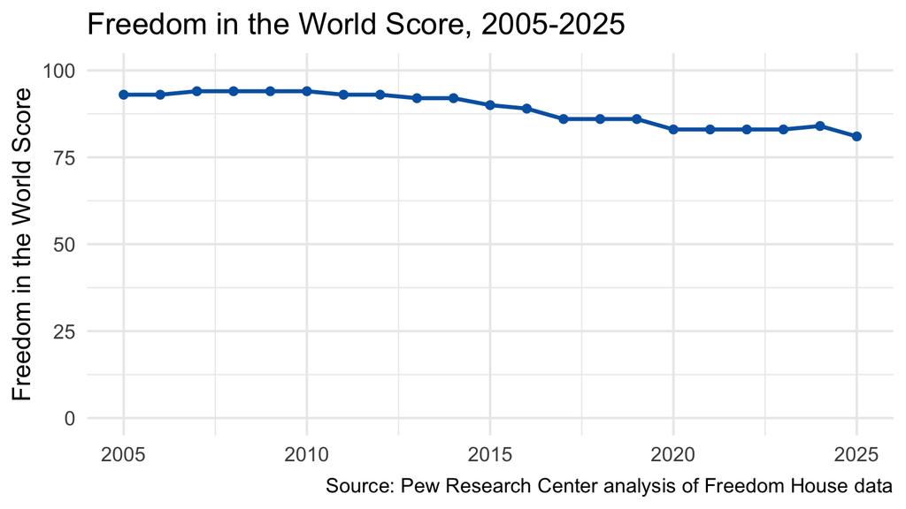

## Measuring Democracy

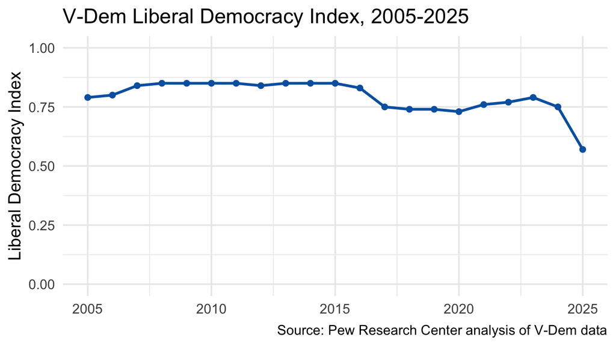

## Forms of Government from Left to Right

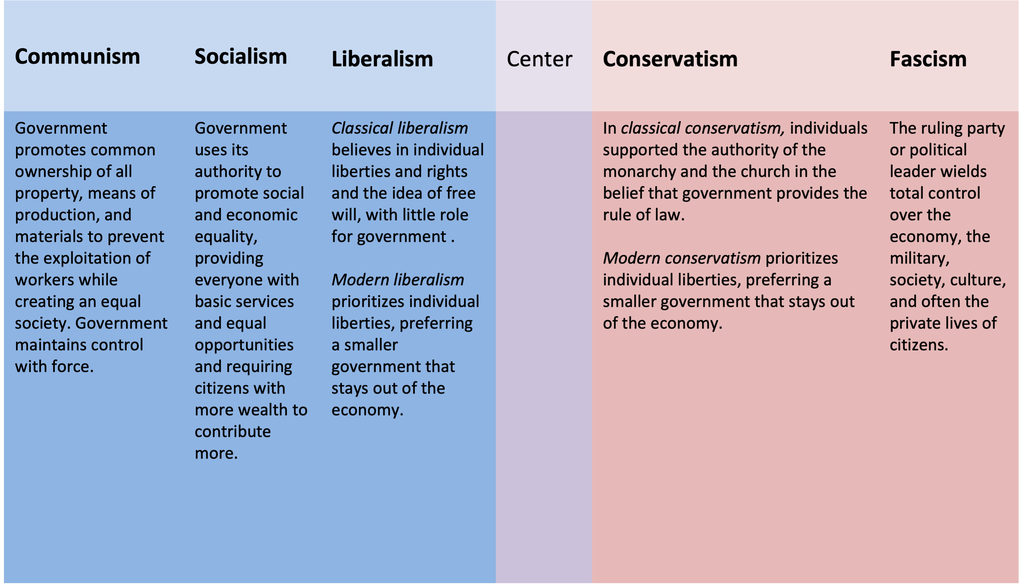

# Who Governs?

## Political Power in America: Five Views

| View | Description | Group(s) in Power |
| --- | --- | --- |
| Class View | Government dominated by capitalists | Capitalists and economic elites |
| Power Elite View | Government dominated by a few top leaders, outside government | Business, military, labor unions, elected officials |
| Bureaucratic View | Government dominated by appointed officials | Appointed bureaucrats |
| Pluralist View | Competition among interests shapes public policy | Representatives of interest groups |
| Creedal Passion View | Morally impassioned elites drive important political change | Morally impassioned elites |

# The Political Agenda

## Who Governs? To What Ends?

- Which groups shape the government and drive policymaking in the United States?
  - Unions? Big business? Special interests? Politicians? The people?
- **Political Agenda**: *Issues that people believe require government action*
  - Does our political agenda reflect a particular group?

# The Politics of Policy Issues

## Costs and Benefits

- **Cost**: *A burden that people believe they must bear if a policy is adopted*
- **Benefit**: *A satisfaction that people believe they will enjoy if a policy is adopted*
- Costs and benefits can be **distributed** (spread broadly across society) or **concentrated** (borne/enjoyed by a small group)

## Four Types of Politics

### Wilson’s Cost-Benefit Framework

[figure not shown]